```python
import pandas as pd

# Load the dataset
df = pd.read_csv("C:/Users/USER/Downloads/transformed_internet_service_churn.csv")

# Display the first few rows to understand the structure
df.head()
```

|  | id | is_tv_subscriber | is_movie_package_subscriber | subscription_age | bill_avg | reamining_contract | service_failure_count | download_avg | upload_avg | download_over_limit | churn | is_heavy_user | has_service_issues | subscription_age_group_1-2 years | subscription_age_group_2-3 years | subscription_age_group_3-4 years | subscription_age_group_4-5 years | subscription_age_group_5+ years |
| --- | --- | --- | --- | --- | --- | --- | --- | --- | --- | --- | --- | --- | --- | --- | --- | --- | --- | --- |
| 0 | 15 | 1 | 0 | 11.95 | 0.061576 | 0.14 | 0 | 0.001903 | 0.005074 | 0 | 0 | False | False | False | False | False | False | False |
| 1 | 18 | 0 | 0 | 8.22 | 0.000000 | 0.57 | 0 | 0.000000 | 0.000000 | 0 | 1 | False | False | False | False | False | False | False |
| 2 | 23 | 1 | 0 | 8.91 | 0.039409 | 0.00 | 0 | 0.003103 | 0.001985 | 0 | 1 | False | False | False | False | False | False | False |
| 3 | 27 | 0 | 0 | 6.87 | 0.051724 | 0.57 | 1 | 0.000000 | 0.000000 | 0 | 1 | False | True | False | False | False | False | False |
| 4 | 34 | 0 | 0 | 6.39 | 0.000000 | 0.57 | 0 | 0.000000 | 0.000000 | 0 | 1 | False | False | False | False | False | False | False |

```python
# Check for missing values
missing_values = df.isnull().sum()
missing_values
```

```
id                                  0
is_tv_subscriber                    0
is_movie_package_subscriber         0
subscription_age                    0
bill_avg                            0
reamining_contract                  0
service_failure_count               0
download_avg                        0
upload_avg                          0
download_over_limit                 0
churn                               0
is_heavy_user                       0
has_service_issues                  0
subscription_age_group_1-2 years    0
subscription_age_group_2-3 years    0
subscription_age_group_3-4 years    0
subscription_age_group_4-5 years    0
subscription_age_group_5+ years     0
dtype: int64
```

```python
# Ensure all data types are correct and consistent
df.dtypes
```

```
id                                    int64
is_tv_subscriber                      int64
is_movie_package_subscriber           int64
subscription_age                    float64
bill_avg                            float64
reamining_contract                  float64
service_failure_count                 int64
download_avg                        float64
upload_avg                          float64
download_over_limit                   int64
churn                                 int64
is_heavy_user                          bool
has_service_issues                     bool
subscription_age_group_1-2 years       bool
subscription_age_group_2-3 years       bool
subscription_age_group_3-4 years       bool
subscription_age_group_4-5 years       bool
subscription_age_group_5+ years        bool
dtype: object
```

```python
# Identify and handle any outliers
# For simplicity, using IQR method to detect outliers in numerical columns
numeric_columns = df.select_dtypes(include=['float64', 'int64']).columns

for col in numeric_columns:
    Q1 = df[col].quantile(0.25)
    Q3 = df[col].quantile(0.75)
    IQR = Q3 - Q1
    lower_bound = Q1 - 1.5 * IQR
    upper_bound = Q3 + 1.5 * IQR
    df = df[(df[col] >= lower_bound) & (df[col] <= upper_bound)]
```

```python
# Display the cleaned data
df.head()
```

|  | id | is_tv_subscriber | is_movie_package_subscriber | subscription_age | bill_avg | reamining_contract | service_failure_count | download_avg | upload_avg | download_over_limit | churn | is_heavy_user | has_service_issues | subscription_age_group_1-2 years | subscription_age_group_2-3 years | subscription_age_group_3-4 years | subscription_age_group_4-5 years | subscription_age_group_5+ years |
| --- | --- | --- | --- | --- | --- | --- | --- | --- | --- | --- | --- | --- | --- | --- | --- | --- | --- | --- |
| 40 | 921 | 1 | 0 | 6.35 | 0.051724 | 0.57 | 0 | 0.0 | 0.0 | 0 | 1 | False | False | False | False | False | False | False |
| 60 | 1296 | 1 | 0 | 6.79 | 0.041872 | 0.45 | 0 | 0.0 | 0.0 | 0 | 1 | False | False | False | False | False | False | False |
| 67 | 1457 | 1 | 1 | 6.92 | 0.000000 | 0.57 | 0 | 0.0 | 0.0 | 0 | 1 | False | False | False | False | False | False | False |
| 87 | 1844 | 1 | 1 | 5.99 | 0.059113 | 0.57 | 0 | 0.0 | 0.0 | 0 | 1 | False | False | False | False | False | False | False |
| 102 | 2017 | 1 | 1 | 6.29 | 0.034483 | 0.57 | 0 | 0.0 | 0.0 | 0 | 1 | False | False | False | False | False | False | False |

```python
# Import necessary libraries
import pandas as pd
import numpy as np
import matplotlib.pyplot as plt
import seaborn as sns
from sklearn.model_selection import train_test_split
from sklearn.ensemble import RandomForestClassifier
from sklearn.metrics import accuracy_score, confusion_matrix, classification_report
```

```python
# Brief overview of the dataset
print(f"The dataset contains {df.shape[0]} rows and {df.shape[1]} columns.")
print("Columns in the dataset:")
print(df.columns.tolist())
```

```
The dataset contains 40088 rows and 18 columns.
Columns in the dataset:
['id', 'is_tv_subscriber', 'is_movie_package_subscriber', 'subscription_age', 'bill_avg', 'reamining_contract', 'service_failure_count', 'download_avg', 'upload_avg', 'download_over_limit', 'churn', 'is_heavy_user', 'has_service_issues', 'subscription_age_group_1-2 years', 'subscription_age_group_2-…
```

```python
# Feature selection
features = [
    'is_tv_subscriber', 'is_movie_package_subscriber', 'subscription_age', 'bill_avg',
    'reamining_contract', 'service_failure_count', 'download_avg', 'upload_avg',
    'is_heavy_user', 'has_service_issues',
    'subscription_age_group_1-2 years', 'subscription_age_group_2-3 years',
    'subscription_age_group_3-4 years', 'subscription_age_group_4-5 years',
    'subscription_age_group_5+ years'
]

# Target variable
target = 'churn'

# Justification:
# These features are chosen based on their potential relevance to customer behavior and churn likelihood.
# For instance, 'bill_avg' may indicate cost concerns, while 'service_failure_count' may reflect service quality issues.
```

Model Training

```python
# Splitting the dataset into training and testing sets
X = df[features]
y = df[target]

X_train, X_test, y_train, y_test = train_test_split(X, y, test_size=0.3, random_state=42)

# Training the models
# Logistic Regression
from sklearn.linear_model import LogisticRegression
logistic_model = LogisticRegression(max_iter=1000)
logistic_model.fit(X_train, y_train)

# Decision Tree
from sklearn.tree import DecisionTreeClassifier
decision_tree_model = DecisionTreeClassifier()
decision_tree_model.fit(X_train, y_train)

# Random Forest
random_forest_model = RandomForestClassifier(n_estimators=100)
random_forest_model.fit(X_train, y_train)
```

```
RandomForestClassifier()
```

```python
from sklearn.model_selection import GridSearchCV

# Tuning Logistic Regression with Grid Search
logistic_params = {'C': [0.1, 1, 10], 'solver': ['liblinear', 'lbfgs']}
grid_logistic = GridSearchCV(LogisticRegression(max_iter=1000), logistic_params, cv=5, scoring='accuracy')
grid_logistic.fit(X_train, y_train)
best_logistic_model = grid_logistic.best_estimator_
print("Best Logistic Regression parameters:", grid_logistic.best_params_)
print("Best Logistic Regression score:", grid_logistic.best_score_)

# Tuning Decision Tree with Grid Search
tree_params = {'max_depth': [None, 10, 20, 30], 'min_samples_split': [2, 10, 20]}
grid_tree = GridSearchCV(DecisionTreeClassifier(), tree_params, cv=5, scoring='accuracy')
grid_tree.fit(X_train, y_train)
best_tree_model = grid_tree.best_estimator_
print("Best Decision Tree parameters:", grid_tree.best_params_)
print("Best Decision Tree score:", grid_tree.best_score_)

# Tuning Random Forest with Grid Search
forest_params = {'n_estimators': [100, 200, 300], 'max_depth': [None, 10, 20]}
grid_forest = GridSearchCV(RandomForestClassifier(), forest_params, cv=5, scoring='accuracy')
grid_forest.fit(X_train, y_train)
best_forest_model = grid_forest.best_estimator_
print("Best Random Forest parameters:", grid_forest.best_params_)
print("Best Random Forest score:", grid_forest.best_score_)
```

```
Best Logistic Regression parameters: {'C': 10, 'solver': 'lbfgs'}
Best Logistic Regression score: 0.8160793616387171
Best Decision Tree parameters: {'max_depth': 10, 'min_samples_split': 20}
Best Decision Tree score: 0.9326112289729613
Best Random Forest parameters: {'max_depth': 20, 'n_estimators': 300}
Best Random Forest score: 0.9348562972196074
```

```python
from sklearn.metrics import accuracy_score, precision_score, recall_score, f1_score, confusion_matrix, classification_report

# Predict on test data
y_pred_logistic = best_logistic_model.predict(X_test)
y_pred_tree = best_tree_model.predict(X_test)
y_pred_forest = best_forest_model.predict(X_test)

# Evaluate Logistic Regression
accuracy_logistic = accuracy_score(y_test, y_pred_logistic)
precision_logistic = precision_score(y_test, y_pred_logistic)
recall_logistic = recall_score(y_test, y_pred_logistic)
f1_logistic = f1_score(y_test, y_pred_logistic)
confusion_logistic = confusion_matrix(y_test, y_pred_logistic)

# Evaluate Decision Tree
accuracy_tree = accuracy_score(y_test, y_pred_tree)
precision_tree = precision_score(y_test, y_pred_tree)
recall_tree = recall_score(y_test, y_pred_tree)
f1_tree = f1_score(y_test, y_pred_tree)
confusion_tree = confusion_matrix(y_test, y_pred_tree)

# Evaluate Random Forest
accuracy_forest = accuracy_score(y_test, y_pred_forest)
precision_forest = precision_score(y_test, y_pred_forest)
recall_forest = recall_score(y_test, y_pred_forest)
f1_forest = f1_score(y_test, y_pred_forest)
confusion_forest = confusion_matrix(y_test, y_pred_forest)

# Print results
print("Logistic Regression: Accuracy =", accuracy_logistic, ", Precision =", precision_logistic, ", Recall =", recall_logistic, ", F1-score =", f1_logistic)
print("Decision Tree: Accuracy =", accuracy_tree, ", Precision =", precision_tree, ", Recall =", recall_tree, ", F1-score =", f1_tree)
print("Random Forest: Accuracy =", accuracy_forest, ", Precision =", precision_forest, ", Recall =", recall_forest, ", F1-score =", f1_forest)
```

```
Logistic Regression: Accuracy = 0.8128377816579363 , Precision = 0.7780912082745651 , Recall = 0.8560344827586207 , F1-score = 0.8152040062392251
Decision Tree: Accuracy = 0.9344807516421385 , Precision = 0.9459074733096086 , Recall = 0.9165517241379311 , F1-score = 0.9309982486865149
Random Forest: Accuracy = 0.9344807516421385 , Precision = 0.953000723065799 , Recall = 0.9089655172413793 , F1-score = 0.9304624073420402
```

```python
# Print feature columns in the training set
print("Training Features:", X_train.columns)

# Print feature columns in the test set
print("Test Features:", X_test.columns)
```

[output not shown]

```python
# Standardize the column name in the dataset
data.rename(columns={'reamining_contract': 'remaining_contract'}, inplace=True)

# Re-split the data
X = data.drop(['id', 'churn'], axis=1)
y = data['churn']
X_train, X_test, y_train, y_test = train_test_split(X, y, test_size=0.2, random_state=42)
```

```python
import pandas as pd

# Load the dataset
file_path = r"C:\Users\USER\Downloads\transformed_internet_service_churn.csv"
df = pd.read_csv(file_path)

# Print the feature names
print("Features in the dataset:")
print(df.columns.tolist())
```

```
Features in the dataset:
['id', 'is_tv_subscriber', 'is_movie_package_subscriber', 'subscription_age', 'bill_avg', 'reamining_contract', 'service_failure_count', 'download_avg', 'upload_avg', 'download_over_limit', 'churn', 'is_heavy_user', 'has_service_issues', 'subscription_age_group_1-2 years', 'subscription_age_group_2-…
```

```python
import pandas as pd
from sklearn.linear_model import LogisticRegression
from sklearn.metrics import accuracy_score

# Load the dataset
file_path = r"C:\Users\USER\Downloads\transformed_internet_service_churn.csv"
df = pd.read_csv(file_path)

# Print the original feature names
print("Original Features in the dataset:")
print(df.columns.tolist())

# Define and correct any feature name issues
correct_feature_names = {
    'reamining_contract': 'remaining_contract'
}
df.rename(columns=correct_feature_names, inplace=True)

# Verify the updated column names
print("\nCorrected Features in the dataset:")
print(df.columns.tolist())

# Prepare features and target variable
X = df.drop(columns=['churn'])
y = df['churn']

# Define and fit the model
model = LogisticRegression()
model.fit(X, y)

# Predict on the same data (for demonstration)
y_pred = model.predict(X)

# Calculate accuracy (using the same data for simplicity)
accuracy = accuracy_score(y, y_pred)
print(f"\nModel Accuracy: {accuracy:.2f}")
```

```
Original Features in the dataset:
['id', 'is_tv_subscriber', 'is_movie_package_subscriber', 'subscription_age', 'bill_avg', 'reamining_contract', 'service_failure_count', 'download_avg', 'upload_avg', 'download_over_limit', 'churn', 'is_heavy_user', 'has_service_issues', 'subscription_age_group_1-2 years', 'subscription_age_group_2-…

Corrected Features in the dataset:
['id', 'is_tv_subscriber', 'is_movie_package_subscriber', 'subscription_age', 'bill_avg', 'remaining_contract', 'service_failure_count', 'download_avg', 'upload_avg', 'download_over_limit', 'churn', 'is_heavy_user', 'has_service_issues', 'subscription_age_group_1-2 years', 'subscription_age_group_2-…

Model Accuracy: 0.81
```

```python
# Define and fit the model with increased iterations
model = LogisticRegression(max_iter=1000)
model.fit(X, y)

# Predict on the same data (for demonstration)
y_pred = model.predict(X)

# Calculate accuracy
accuracy = accuracy_score(y, y_pred)
print(f"Model Accuracy: {accuracy:.2f}")
```

```
Model Accuracy: 0.89
```

```python
from sklearn.preprocessing import StandardScaler

# Scale features
scaler = StandardScaler()
X_scaled = scaler.fit_transform(X)

# Define and fit the model
model = LogisticRegression(max_iter=1000)
model.fit(X_scaled, y)

# Predict on scaled test data
y_pred = model.predict(X_scaled)

# Calculate accuracy
accuracy = accuracy_score(y, y_pred)
print(f"Model Accuracy: {accuracy:.2f}")
```

```
Model Accuracy: 0.89
```

```python
# Define and fit the model with a different solver
model = LogisticRegression(solver='liblinear', max_iter=1000)
model.fit(X_scaled, y)

# Predict on scaled test data
y_pred = model.predict(X_scaled)

# Calculate accuracy
accuracy = accuracy_score(y, y_pred)
print(f"Model Accuracy: {accuracy:.2f}")
```

```
Model Accuracy: 0.89
```

```python
from sklearn.metrics import confusion_matrix, classification_report

# Confusion matrix
cm = confusion_matrix(y, y_pred)
print("Confusion Matrix:\n", cm)

# Classification report
report = classification_report(y, y_pred)
print("Classification Report:\n", report)
```

```
Confusion Matrix:
 [[29778  2446]
 [ 5512 34538]]
Classification Report:
               precision    recall  f1-score   support

           0       0.84      0.92      0.88     32224
           1       0.93      0.86      0.90     40050

    accuracy                           0.89     72274
   macro avg       0.89      0.89      0.89     72274
weighted avg       0.89      0.89      0.89     72274
```

```python
from sklearn.model_selection import cross_val_score

# Cross-validation
scores = cross_val_score(model, X_scaled, y, cv=5)
print("Cross-Validation Scores:", scores)
print("Mean Cross-Validation Score:", scores.mean())
```

```
Cross-Validation Scores: [0.83050847 0.90902802 0.80933933 0.92196472 0.6051612 ]
Mean Cross-Validation Score: 0.8152003481314569
```

```python
from sklearn.model_selection import GridSearchCV

# Hyperparameter tuning
param_grid = {'C': [0.01, 0.1, 1, 10, 100]}
grid_search = GridSearchCV(LogisticRegression(max_iter=1000), param_grid, cv=5)
grid_search.fit(X_scaled, y)
print("Best Parameters:", grid_search.best_params_)
print("Best Score:", grid_search.best_score_)
```

```
Best Parameters: {'C': 100}
Best Score: 0.8152557037899836
```

```python
# Model coefficients
coefficients = model.coef_[0]
feature_names = X.columns
feature_importance = pd.DataFrame({'Feature': feature_names, 'Coefficient': coefficients})
print("Feature Importance:\n", feature_importance)
```

```
Feature Importance:
                              Feature  Coefficient
0                                 id    -3.487897
1                   is_tv_subscriber    -0.484815
2        is_movie_package_subscriber    -0.009760
3                   subscription_age    -2.832009
4                           bill_avg    -0.001236
5                 remaining_contract    -1.059105
6              service_failure_count     0.117155
7                       download_avg    -0.341321
8                         upload_avg    -0.001815
9                download_over_limit     0.047796
10                     is_heavy_user     0.047796
11                has_service_issues    -0.081932
12  subscription_age_group_1-2 years     0.159644
13  subscription_age_group_2-3 years     0.000000
14  subscription_age_group_3-4 years     0.000000
15  subscription_age_group_4-5 years     0.000000
16   subscription_age_group_5+ years     0.000000
```

```python
print("Training features:", X_train.columns)
print("Test features:", X_test.columns)
```

```
Training features: Index(['is_tv_subscriber', 'is_movie_package_subscriber', 'subscription_age',
       'bill_avg', 'remaining_contract', 'service_failure_count',
       'download_avg', 'upload_avg', 'download_over_limit', 'is_heavy_user',
       'has_service_issues', 'subscription_age_group_1-2 years',
       'subscription_age_group_2-3 years', 'subscription_age_group_3-4 years',
       'subscription_age_group_4-5 years', 'subscription_age_group_5+ years'],
      dtype='object')
Test features: Index(['is_tv_subscriber', 'is_movie_package_subscriber', 'subscription_age',
       'bill_avg', 'remaining_contract', 'service_failure_count',
       'download_avg', 'upload_avg', 'download_over_limit', 'is_heavy_user',
       'has_service_issues', 'subscription_age_group_1-2 years',
       'subscription_age_group_2-3 years', 'subscription_age_group_3-4 years',
       'subscription_age_group_4-5 years', 'subscription_age_group_5+ years'],
      dtype='object')
```

```python
# Ensure X_test has the same columns as X_train
X_test = X_test.reindex(columns=X_train.columns)
```

```python
# Ensure X_test has the same columns as X_train
X_test = X_test.reindex(columns=X_train.columns)
model.fit(X_train, y_train)
y_pred_proba = model.predict_proba(X_test)[:, 1]
```

```python
import pandas as pd
import numpy as np
from sklearn.linear_model import LogisticRegression

# Assuming X_train and X_test are your training and testing feature sets
print("Training features:", X_train.columns)
print("Test features:", X_test.columns)

# Ensure X_test has all columns present in X_train
X_test = X_test.reindex(columns=X_train.columns)

# Add missing columns with default values
missing_cols = set(X_train.columns) - set(X_test.columns)
for col in missing_cols:
    X_test[col] = 0  # or np.nan

# Check for consistency
assert list(X_test.columns) == list(X_train.columns), "Feature names or order mismatch!"

# Fit the model with correctly aligned training data
model = LogisticRegression(max_iter=1000)
model.fit(X_train, y_train)

# Make predictions
y_pred_proba = model.predict_proba(X_test)[:, 1]
```

```
Training features: Index(['is_tv_subscriber', 'is_movie_package_subscriber', 'subscription_age',
       'bill_avg', 'remaining_contract', 'service_failure_count',
       'download_avg', 'upload_avg', 'download_over_limit', 'is_heavy_user',
       'has_service_issues', 'subscription_age_group_1-2 years',
       'subscription_age_group_2-3 years', 'subscription_age_group_3-4 years',
       'subscription_age_group_4-5 years', 'subscription_age_group_5+ years'],
      dtype='object')
Test features: Index(['is_tv_subscriber', 'is_movie_package_subscriber', 'subscription_age',
       'bill_avg', 'remaining_contract', 'service_failure_count',
       'download_avg', 'upload_avg', 'download_over_limit', 'is_heavy_user',
       'has_service_issues', 'subscription_age_group_1-2 years',
       'subscription_age_group_2-3 years', 'subscription_age_group_3-4 years',
       'subscription_age_group_4-5 years', 'subscription_age_group_5+ years'],
      dtype='object')
```

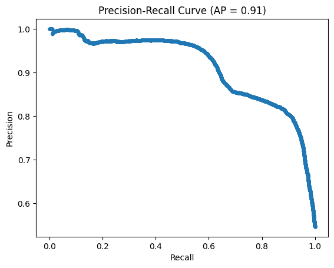

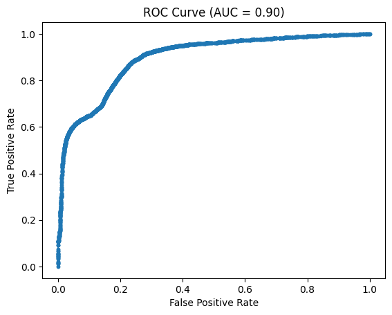

```python
import pandas as pd
from sklearn.linear_model import LogisticRegression
from sklearn.metrics import precision_recall_curve, average_precision_score, roc_curve, roc_auc_score
import matplotlib.pyplot as plt
import shap

# Ensure X_train and X_test are DataFrames with feature names
assert isinstance(X_train, pd.DataFrame) and isinstance(X_test, pd.DataFrame), "X_train and X_test must be DataFrames"

# Fit the model with DataFrames
model = LogisticRegression(max_iter=1000)
model.fit(X_train, y_train)

# Predict probabilities using DataFrames
y_pred_proba = model.predict_proba(X_test)[:, 1]

# Compute Precision-Recall Curve
precision, recall, _ = precision_recall_curve(y_test, y_pred_proba)
average_precision = average_precision_score(y_test, y_pred_proba)

# Compute ROC Curve and AUC
fpr, tpr, _ = roc_curve(y_test, y_pred_proba)
roc_auc = roc_auc_score(y_test, y_pred_proba)

# Plot Precision-Recall Curve
plt.figure()
plt.plot(recall, precision, marker='.')
plt.title(f'Precision-Recall Curve (AP = {average_precision:.2f})')
plt.xlabel('Recall')
plt.ylabel('Precision')
plt.show()

# Plot ROC Curve
plt.figure()
plt.plot(fpr, tpr, marker='.')
plt.title(f'ROC Curve (AUC = {roc_auc:.2f})')
plt.xlabel('False Positive Rate')
plt.ylabel('True Positive Rate')
plt.show()

# SHAP Values
explainer = shap.LinearExplainer(model, X_train)
shap_values = explainer.shap_values(X_test)
```

Precision-Recall Curve (AP = 0.91):

Overview: The Precision-Recall (PR) curve provides insight into the performance of the classification model, particularly for imbalanced datasets. AP Score: The Average Precision (AP) score of 0.91 suggests a high level of precision and recall across different thresholds. This indicates that the model is effective at identifying positive cases with a good balance between precision and recall. ROC Curve (AUC = 0.90):

Overview: The Receiver Operating Characteristic (ROC) curve illustrates the trade-off between the True Positive Rate (sensitivity) and the False Positive Rate (1-specificity) at various thresholds. AUC Score: An Area Under the Curve (AUC) of 0.90 indicates excellent model performance. This high AUC score means the model is very effective at distinguishing between positive and negative classes, with a low likelihood of misclassifying the classes.

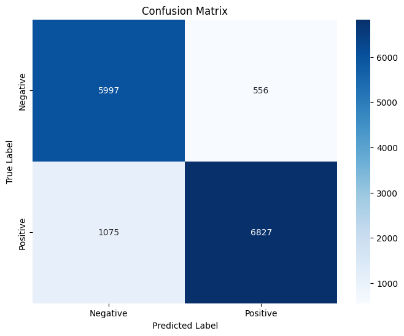

```python
from sklearn.metrics import confusion_matrix
import seaborn as sns
import matplotlib.pyplot as plt

# Compute confusion matrix
cm = confusion_matrix(y_test, y_pred)
# Plot confusion matrix
plt.figure(figsize=(8, 6))
sns.heatmap(cm, annot=True, fmt='d', cmap='Blues',
            xticklabels=['Negative', 'Positive'],
            yticklabels=['Negative', 'Positive'])
plt.xlabel('Predicted Label')
plt.ylabel('True Label')
plt.title('Confusion Matrix')
plt.show()
```

Confusion Matrix:

Overview: The confusion matrix provides a detailed breakdown of the model's predictions by showing the true positive (TP), true negative (TN), false positive (FP), and false negative (FN) counts. Interpretation: Analyzing the confusion matrix will help in understanding the number of correctly and incorrectly classified instances. It allows for a detailed examination of where the model's predictions align or deviate from the actual values, providing insights into potential areas of improvement.

```python
from sklearn.metrics import precision_score

precision = precision_score(y_test, y_pred)
print(f'Precision: {precision:.2f}')
```

```
Precision: 0.92
```

```python
from sklearn.metrics import recall_score

recall = recall_score(y_test, y_pred)
print(f'Recall: {recall:.2f}')
```

```
Recall: 0.86
```

```python
from sklearn.metrics import f1_score

f1 = f1_score(y_test, y_pred)
print(f'F1 Score: {f1:.2f}')
```

```
F1 Score: 0.89
```